# Exploring University of Oregon Data with the College Scorecard API

Maithreyi Gopalan

2026-01-14

# Introduction

This tutorial demonstrates how to download and analyze higher education data using the College Scorecard API. The College Scorecard provides data on college costs, student outcomes, and institutional characteristics for colleges and universities across the United States.

We’ll focus on University of Oregon data and make comparisons with other institutions.

## Getting Started

### Step 1: Get Your API Key

Before running this code, you need to get a free API key:

1. Go to: https://api.data.gov/signup/
2. Fill out the form (takes less than 1 minute)
3. Check your email for your API key
4. Copy your API key and paste it in the setup chunk below

### Step 2: Install Required Packages

Run this code once to install the necessary packages:

```r
# Only run this once
install.packages("rscorecard")
install.packages("tidyverse")
```

# Setup

```r
# Load required packages
library(rscorecard)
library(tidyverse)
library(knitr)

# Set your API key here
# Replace 'YOUR_API_KEY_HERE' with your actual key from https://api.data.gov/signup/
sc_key('krza60yel5q738DvsMBdLrVGzBJsRLIIpMAQgdJ1')

# Set chunk options
knitr::opts_chunk$set(
  echo = TRUE,
  message = FALSE,
  warning = FALSE,
  fig.width = 10,
  fig.height = 6
)
```

# Basic University of Oregon Data

Let’s start by getting basic information about the University of Oregon.

```r
# Get basic UO data - using unitid for exact match
uo_data <- sc_init() %>%
    sc_filter(unitid == 209551) %>%  # UO's specific unitid
    sc_select(unitid, instnm, stabbr, city, locale) %>%
    sc_year("latest") %>%
    sc_get()

# Display the data
kable(uo_data, caption = "Basic University of Oregon Information")
```

Basic University of Oregon Information

| unitid | instnm | stabbr | city | locale | year |
| --- | --- | --- | --- | --- | --- |
| 209551 | University of Oregon | OR | Eugene | 12 | latest |

# University of Oregon Trends Over Time

Now let’s examine how enrollment and costs have changed at UO from 2010 to 2020.

```r
# Get UO enrollment and cost data over time
# Need to get each year separately and combine
years_to_get <- 2010:2020

uo_trends <- map_dfr(years_to_get, function(yr) {
  sc_init() %>%
    sc_filter(unitid == 209551) %>%
    sc_select(instnm, ugds, costt4_a, tuitionfee_in, tuitionfee_out) %>%
    sc_year(yr) %>%
    sc_get()
})

# Convert year to numeric for plotting
uo_trends <- uo_trends %>%
  mutate(year_numeric = as.numeric(year))

# Display the data
kable(uo_trends %>% select(-year_numeric),
      caption = "University of Oregon Enrollment and Cost Trends (2010-2020)",
      col.names = c("Institution", "Total Undergrads", "Avg Cost",
                    "In-State Tuition", "Out-of-State Tuition", "Year"))
```

University of Oregon Enrollment and Cost Trends (2010-2020)

| Institution | Total Undergrads | Avg Cost | In-State Tuition | Out-of-State Tuition | Year |
| --- | --- | --- | --- | --- | --- |
| University of Oregon | 19219 | 19343 | 8190 | 25830 | 2010 |
| University of Oregon | 20248 | 20343 | 8789 | 27653 | 2011 |
| University of Oregon | 20464 | 21638 | 9310 | 28660 | 2012 |
| University of Oregon | 20473 | 22390 | 9763 | 29788 | 2013 |
| University of Oregon | 20252 | 23055 | 9918 | 30888 | 2014 |
| University of Oregon | 20220 | 23373 | 10289 | 32024 | 2015 |
| University of Oregon | 19775 | 24209 | 10761 | 33441 | 2016 |
| University of Oregon | 19163 | 24570 | 11931 | 34611 | 2017 |
| University of Oregon | 18923 | 25126 | 11898 | 35478 | 2018 |
| University of Oregon | 18743 | 26205 | 12720 | 36615 | 2019 |
| University of Oregon | 17972 | 27717 | 13857 | 39309 | 2020 |

## Variable Definitions

- **ugds**: Total number of undergraduate degree-seeking students
- **costt4_a**: Average annual cost of attendance
- **tuitionfee_in**: In-state tuition and fees
- **tuitionfee_out**: Out-of-state tuition and fees

## Enrollment Visualization

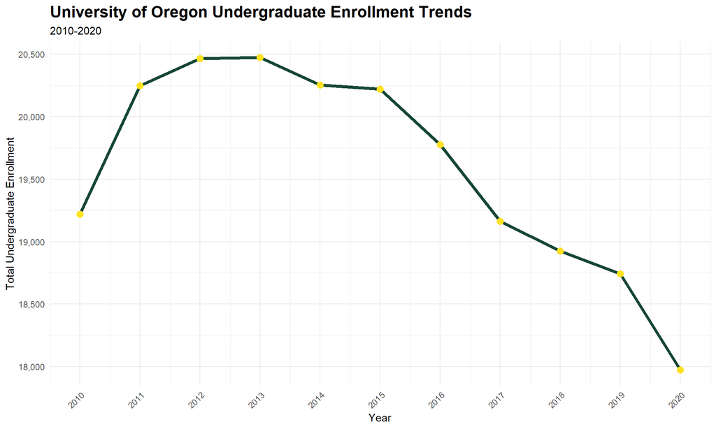

```r
ggplot(uo_trends, aes(x = year, y = ugds)) +
    geom_line(size = 1.5, color = "#154733") +  # UO green
    geom_point(size = 3, color = "#FEE123") +    # UO yellow
    labs(title = "University of Oregon Undergraduate Enrollment Trends",
         subtitle = "2010-2020",
         x = "Year",
         y = "Total Undergraduate Enrollment") +
    scale_x_continuous(breaks = 2010:2020) +
    scale_y_continuous(labels = scales::comma) +
    theme_minimal() +
    theme(plot.title = element_text(face = "bold", size = 16),
          axis.text.x = element_text(angle = 45, hjust = 1))
```

## Tuition Trends Visualization

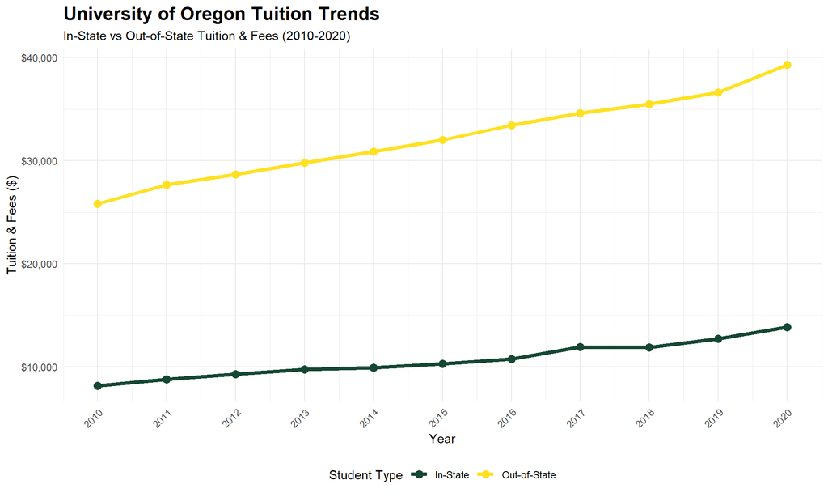

```r
# Reshape data for plotting
uo_tuition_long <- uo_trends %>%
  select(year, tuitionfee_in, tuitionfee_out) %>%
  pivot_longer(cols = c(tuitionfee_in, tuitionfee_out),
               names_to = "tuition_type",
               values_to = "amount") %>%
  mutate(tuition_type = recode(tuition_type,
                                tuitionfee_in = "In-State",
                                tuitionfee_out = "Out-of-State"))

# Create the plot
ggplot(uo_tuition_long, aes(x = year, y = amount, color = tuition_type)) +
    geom_line(size = 1.5) +
    geom_point(size = 3) +
    labs(title = "University of Oregon Tuition Trends",
         subtitle = "In-State vs Out-of-State Tuition & Fees (2010-2020)",
         x = "Year",
         y = "Tuition & Fees ($)",
         color = "Student Type") +
    scale_color_manual(values = c("In-State" = "#154733",
                                   "Out-of-State" = "#FEE123")) +
    scale_x_continuous(breaks = 2010:2020) +
    scale_y_continuous(labels = scales::dollar) +
    theme_minimal() +
    theme(plot.title = element_text(face = "bold", size = 16),
          axis.text.x = element_text(angle = 45, hjust = 1),
          legend.position = "bottom")
```

# Comparing Oregon Universities

Let’s compare UO to other major Oregon universities.

```r
# Compare UO to Oregon State and Portland State
# Compare UO to Oregon State and Portland State using unitids
oregon_comparison <- sc_init() %>%
    sc_filter(unitid == c(209551, 209542, 209807)) %>%  # UO, OSU, PSU
    sc_select(instnm, ugds, adm_rate, sat_avg,
              tuitionfee_in, pctfloan) %>%
    sc_year("latest") %>%
    sc_get()

# Display the comparison
kable(oregon_comparison,
      digits = 2,
      caption = "Comparison of Major Oregon Universities",
      col.names = c("Institution", "Enrollment", "Admission Rate",
                    "Avg SAT", "In-State Tuition", "% Federal Loans", "Year"))
```

Comparison of Major Oregon Universities

| Institution | Enrollment | Admission Rate | Avg SAT | In-State Tuition | % Federal Loans | Year |
| --- | --- | --- | --- | --- | --- | --- |
| Oregon State University | 29557 | 0.79 | NA | 13494 | 0.33 | latest |
| University of Oregon | 19758 | 0.85 | 1257 | 15669 | 0.31 | latest |
| Portland State University | 13619 | 0.91 | NA | 11238 | 0.33 | latest |

## Variable Definitions

- **adm_rate**: Admission rate (proportion of applicants admitted)
- **sat_avg**: Average SAT score (composite)
- **pctfloan**: Percent of students receiving federal student loans

## Visualization: Oregon Universities Comparison

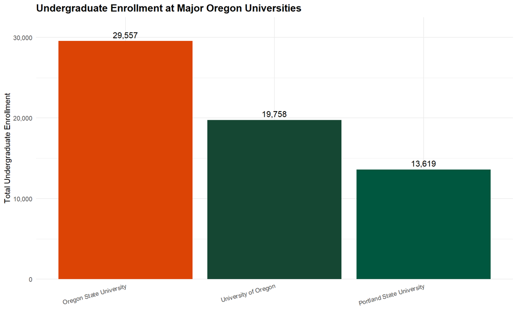

```r
# Create a comparison plot
oregon_comparison %>%
  ggplot(aes(x = reorder(instnm, -ugds), y = ugds, fill = instnm)) +
    geom_col() +
    geom_text(aes(label = scales::comma(ugds)),
              vjust = -0.5, size = 4) +
    labs(title = "Undergraduate Enrollment at Major Oregon Universities",
         x = NULL,
         y = "Total Undergraduate Enrollment") +
    scale_y_continuous(labels = scales::comma,
                       expand = expansion(mult = c(0, 0.1))) +
    scale_fill_manual(values = c("University of Oregon" = "#154733",
                                  "Oregon State University" = "#DC4405",
                                  "Portland State University" = "#00573F")) +
    theme_minimal() +
    theme(legend.position = "none",
          axis.text.x = element_text(angle = 15, hjust = 1),
          plot.title = element_text(face = "bold", size = 14))
```

# Pac-12 Conference Comparison

Let’s see how UO compares to other Pac-12 universities.

```r
# Get Pac-12 universities data using unitids
pac12_unitids <- c(209551,  # University of Oregon
                   236948,  # University of Washington-Seattle
                   110662,  # UCLA
                   110635,  # UC Berkeley
                   123961,  # USC
                   243744,  # Stanford
                   126614,  # Colorado Boulder
                   104179,  # Arizona
                   104151,  # Arizona State-Tempe
                   230764)  # Utah

pac12 <- sc_init() %>%
    sc_filter(unitid %in% pac12_unitids) %>%
    sc_select(instnm, ugds, adm_rate, sat_avg,
              md_earn_wne_p10, grad_debt_mdn) %>%
    sc_year("latest") %>%
    sc_get()

# Display the data
kable(pac12,
      digits = 2,
      caption = "Pac-12 Universities Comparison",
      col.names = c("Institution", "Enrollment", "Admission Rate",
                    "Avg SAT", "Median Earnings (10yr)",
                    "Median Debt", "Year"))
```

Pac-12 Universities Comparison

| Institution | Enrollment | Admission Rate | Avg SAT | Median Earnings (10yr) | Median Debt | Year |
| --- | --- | --- | --- | --- | --- | --- |
| Arizona State University Campus Immersion | 64398 | 0.90 | NA | 62668 | 19500 | latest |
| University of Arizona | 40769 | 0.86 | 1261 | 59979 | 19620 | latest |
| University of California-Berkeley | 33073 | 0.12 | NA | 92446 | 13000 | latest |
| University of California-Los Angeles | 33040 | 0.09 | NA | 82511 | 14000 | latest |
| University of Southern California | 20817 | 0.10 | 1501 | 92498 | 18000 | latest |
| University of Colorado Boulder | 31578 | 0.83 | 1353 | 69738 | 19500 | latest |
| University of Oregon | 19758 | 0.85 | 1257 | 61324 | 20139 | latest |
| University of Utah | 26041 | 0.87 | 1231 | 67170 | 19000 | latest |
| University of Washington-Seattle Campus | 31588 | 0.43 | NA | 78466 | 14615 | latest |
| Stanford University | 7841 | 0.04 | 1553 | 124080 | 12000 | latest |

## Variable Definitions

- **md_earn_wne_p10**: Median earnings of students 10 years after entry
- **grad_debt_mdn**: Median debt for students who completed

## Admission Rates Across Pac-12

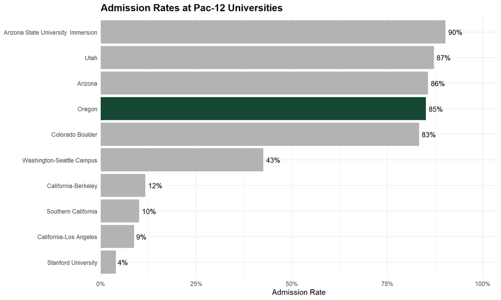

```r
pac12 %>%
  filter(!is.na(adm_rate)) %>%
  mutate(instnm_short = str_remove(instnm, "University of |University-|Campus")) %>%
  ggplot(aes(x = reorder(instnm_short, adm_rate), y = adm_rate)) +
    geom_col(aes(fill = instnm == "University of Oregon")) +
    geom_text(aes(label = scales::percent(adm_rate, accuracy = 1)),
              hjust = -0.2, size = 3.5) +
    coord_flip() +
    labs(title = "Admission Rates at Pac-12 Universities",
         x = NULL,
         y = "Admission Rate") +
    scale_y_continuous(labels = scales::percent,
                       expand = expansion(mult = c(0, 0.15))) +
    scale_fill_manual(values = c("TRUE" = "#154733", "FALSE" = "gray70")) +
    theme_minimal() +
    theme(legend.position = "none",
          plot.title = element_text(face = "bold", size = 14))
```